# Day 1: regression and classification

Seth Flaxman

26/06/2019

```r
library(TH.data)
library(car)
data(bodyfat)
head(bodyfat)
```

```
##    age DEXfat waistcirc hipcirc elbowbreadth kneebreadth anthro3a anthro3b anthro3c anthro4
## 47  57  41.68     100.0   112.0          7.1         9.4     4.42     4.95     4.50    6.13
## 48  65  43.29      99.5   116.5          6.5         8.9     4.63     5.01     4.48    6.37
## 49  59  35.41      96.0   108.5          6.2         8.9     4.12     4.74     4.60    5.82
## 50  58  22.79      72.0    96.5          6.1         9.2     4.03     4.48     3.91    5.66
## 51  60  36.42      89.5   100.5          7.1        10.0     4.24     4.68     4.15    5.91
## 52  61  24.13      83.5    97.0          6.5         8.8     3.55     4.06     3.64    5.14
```

## Regression

**Regression: preliminary tasks**

- Read the documentation for bodyfat by typing ?bodyfat
- Make plots to investigate relationships amongst the predictor variables

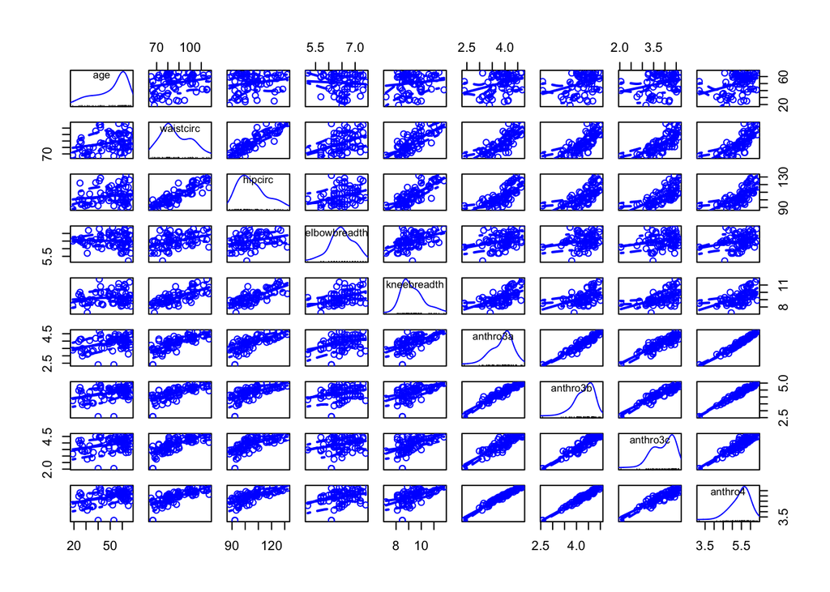

```r
library(car)
scatterplotMatrix(~age+waistcirc+hipcirc+elbowbreadth + kneebreadth + anthro3a + anthro3b + anthro3c + anthro4,data=bodyfat)
```

Visually we can see that a lot of the predictor variables are correlated with each other, which can cause issues for linear regression. We confirm numerically:

```r
round(cor(bodyfat),2)
```

```
##                age DEXfat waistcirc hipcirc elbowbreadth kneebreadth anthro3a anthro3b anthro3c anthro4
## age           1.00   0.27      0.24    0.18        -0.07        0.13     0.33     0.33     0.28    0.34
## DEXfat        0.27   1.00      0.90    0.90         0.35        0.77     0.84     0.81     0.81    0.82
## waistcirc     0.24   0.90      1.00    0.87         0.40        0.73     0.76     0.71     0.74    0.74
## hipcirc       0.18   0.90      0.87    1.00         0.33        0.76     0.71     0.67     0.69    0.69
## elbowbreadth -0.07   0.35      0.40    0.33         1.00        0.46     0.33     0.25     0.24    0.29
## kneebreadth   0.13   0.77      0.73    0.76         0.46        1.00     0.58     0.51     0.54    0.54
## anthro3a      0.33   0.84      0.76    0.71         0.33        0.58     1.00     0.95     0.88    0.98
## anthro3b      0.33   0.81      0.71    0.67         0.25        0.51     0.95     1.00     0.93    0.98
## anthro3c      0.28   0.81      0.74    0.69         0.24        0.54     0.88     0.93     1.00    0.92
## anthro4       0.34   0.82      0.74    0.69         0.29        0.54     0.98     0.98     0.92    1.00
```

- Make plots to investigate relationships between the predictor variables and the label we wish to predict, `DEXfat`

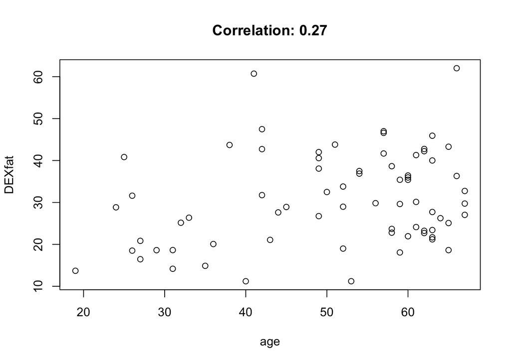

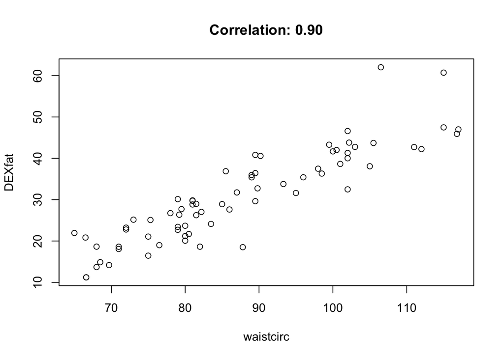

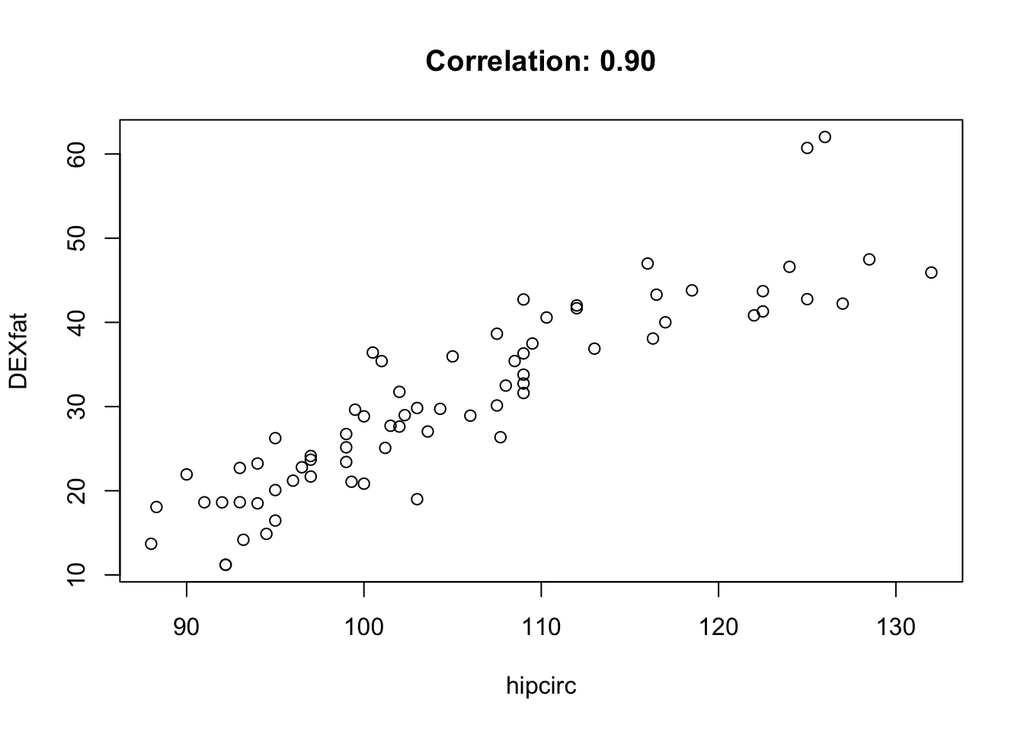

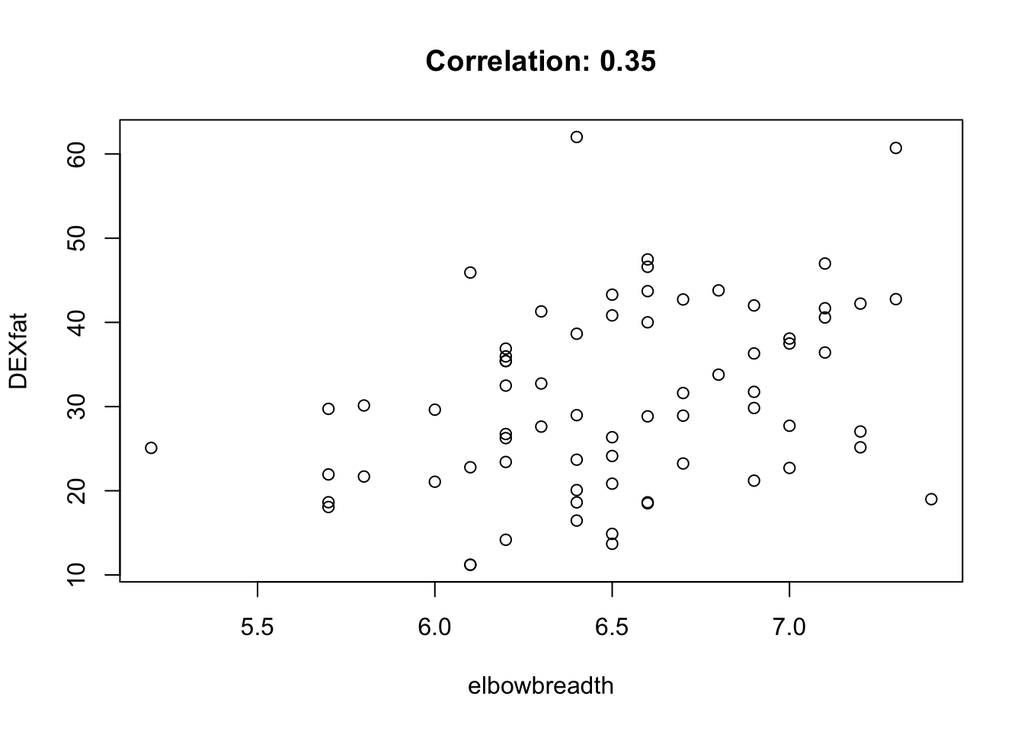

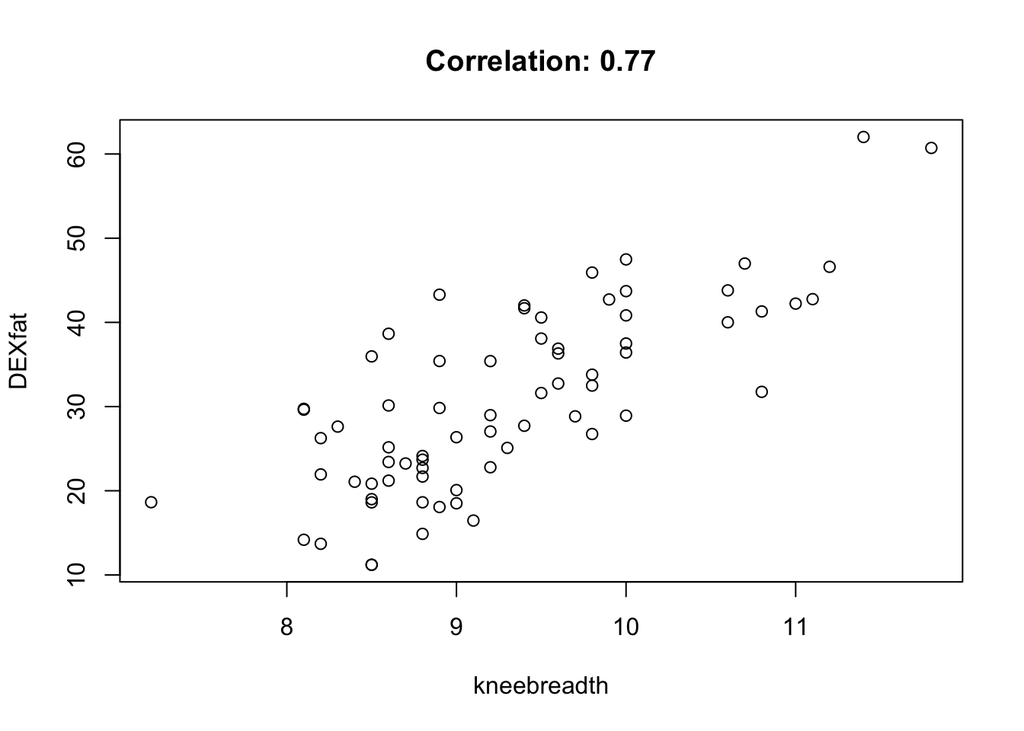

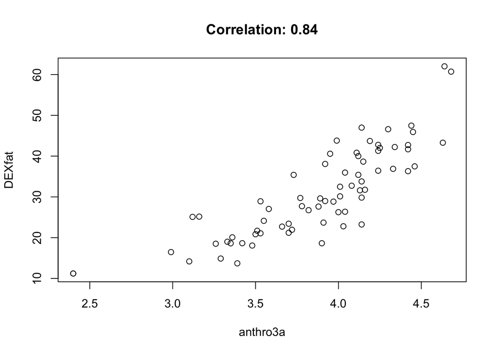

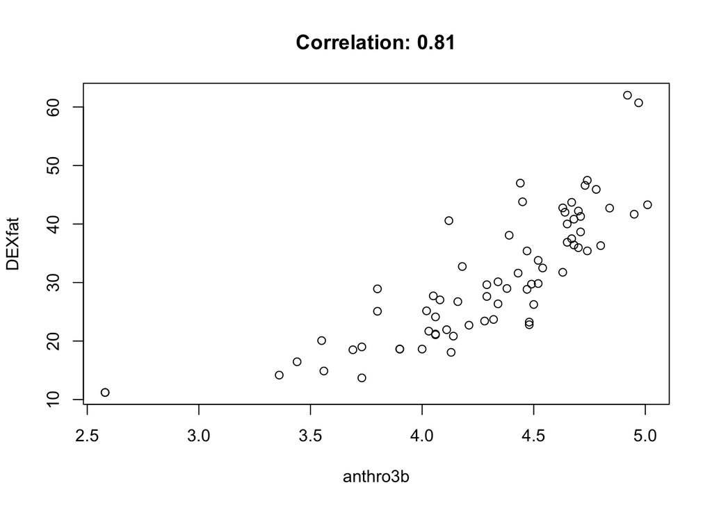

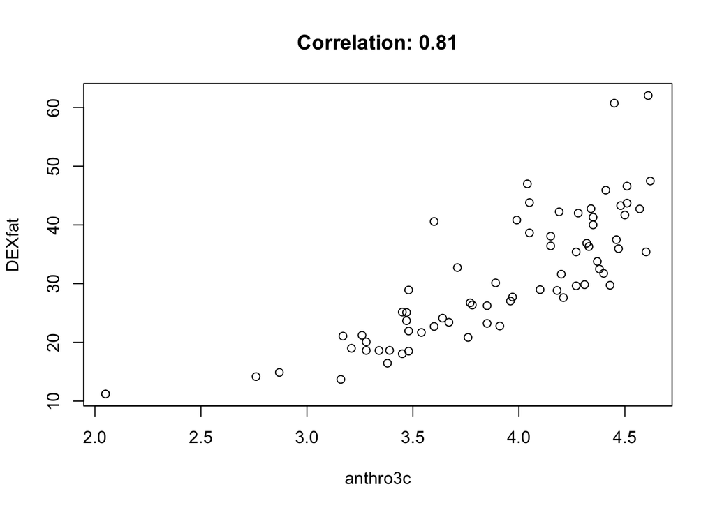

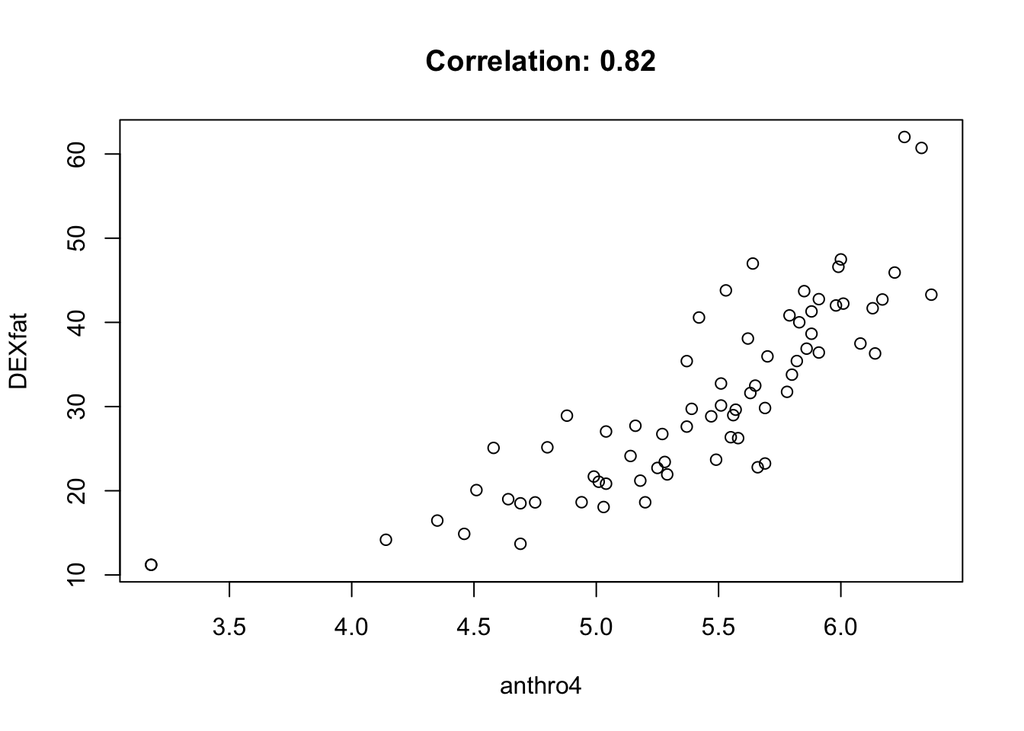

```r
for(v in names(bodyfat)) {
  if(v != "DEXfat")
    plot(bodyfat[,v],bodyfat$DEXfat,xlab=v,ylab="DEXfat",main=sprintf("Correlation: %.02f",cor(bodyfat[,v],bodyfat$DEXfat)))
}
```